# Food_diet_overview_Corona

ben R

06/10/2020

ggplot2 is better than general plot function but im not skilled enough with it as such I will use plot for the majority of the graphing.

```r
##This is for graphics but is not needed if you are using basic plot function like most of the work in this R markdown.
#install.packages("ggplot2")
#library (ggplot2)


#This package is to read in excel documents
#install.packages("readxl")
library(readxl)
```

##Reading in our Food Insecurity Data csv, Your own data may contain large headers (more than just column names) that will make this hard. There are ways to remove the header just ask. Here we accnolage there is a header of column names

```r
corona <- read.csv ("The Impact of the Coronavirus on Food Insecurity v1.csv", header = TRUE)
```

##This is me trying to figure out how to plot WY points on top of the national data. Not realy sure what this will help us understand but it may be a good visual.

```r
#This is currently not running properly :)

#Trying to figure out how to plot wyoing points on top of the national data plot
#Still trying to get this to work
#p<- qplot(Total_Population, X2018_Food_Insecurity_., data=corona,xlab="Total Population", ylab="Percent Food Insecure")

#w <- qplot(Total_Population, X2018_Food_Insecurity_., data= covid_data_wy)+  geom_point(color='darkblue')

#p<-ggplot(aes(Total_Population, X2018_Food_Insecurity_.))+
#geome_point(State ="WY") +
  #geom_point(data=corona, aes(x=Totoal_Population, y=X2018_Food_Insecurity_.), color='yellow', size= 3)

#p<-qplot(Total_Population, X2018_Food_Insecurity_., data=corona,xlab="Total Population", ylab="Percent Food Insecure")+
  #geome_point(State == "WY")

##just and example
#ggplot(aes(x=lifeExp,y=gdpPercap)) +
#  geom_point(alpha=0.3) +
#  geom_point(data=highlight_df, aes(x=lifeExp,y=gdpPercap), color='red',size=3)
#anotherexample
#g1 <- ggplot(corona, State %in% c(na, "WY")), aes(Total_Population, X2018_Food_Insecurity_.)) +
  #geom_point(aes(color = "red"))
#g1 <- ggplot(df, aes(x, y)) +
 # geom_point(aes(color = z2))

#another example
#g2<-ggplot (subset(corona, State %in% c(NA,"WY")))+
 # geom_point(aes(Totoal_Population, X2018_Food_Insedureity_.))
#g2
#ggplot(subset(dat,ID %in% c("P1" , "P3"))) +
#         geom_line(aes(Value1, Value2, group=ID, colour=ID))
#p
#w
#g1
#Determining mean/median population:
#mean(corona$X2018_Food_Insecurity_.)
#median(corona$X2018_Food_Insecurity_.)
```

#This is not a good example Again Not realy certain what this will mean. But All data has been plotted.

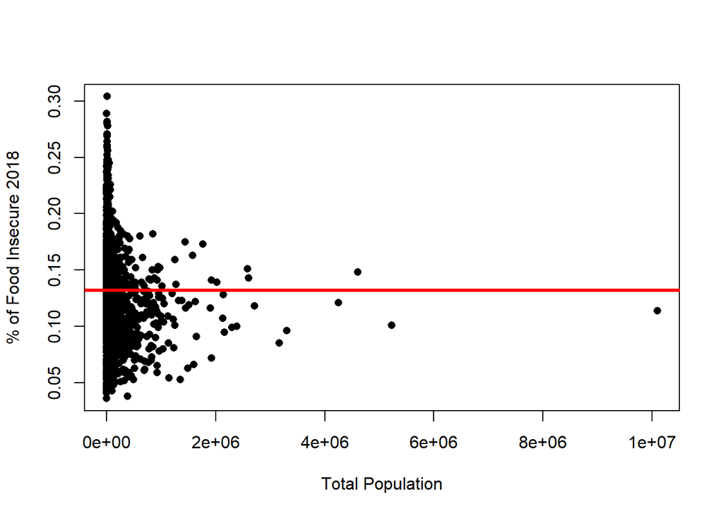

```r
#Not a clue what any of this means
#par(mfrow = c(1,2))
plot (corona$Total_Population, corona$X2018_Food_Insecurity_.,xlab="Total Population", ylab= "% of Food Insecure 2018", pch= 16,)
abline (h = mean(corona$X2018_Food_Insecurity_.), col = "red", lwd=3)
```

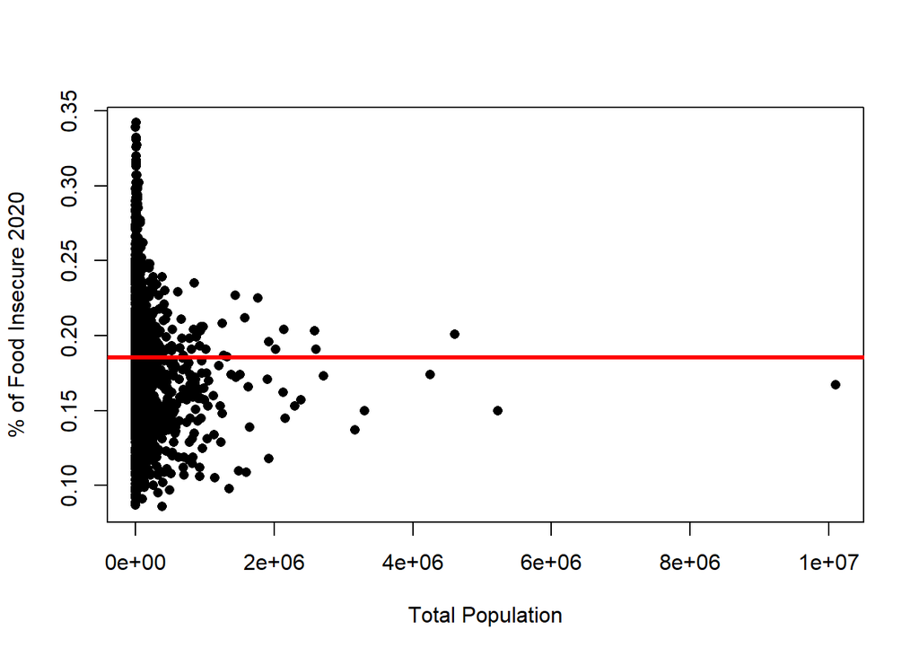

```r
#mtext(side=2, line=3, cex=1, "Mean % Food Insecurity")

plot (corona$Total_Population, corona$X.C._2020_Food_Insecurity_.,xlab="Total Population", ylab= "% of Food Insecure 2020", pch= 16,)
abline (h = mean(corona$X.C._2020_Food_Insecurity_.), col = "red", lwd=3)
```

```r
#text(3,5 "Mean % Food Insecurity")
```

#Subsetting To wyomings Data:

```r
#subsetting Wyoming Data, You do not need to do this if you are smart and know how to subset within the code
covid_data_wy <- corona[corona$State == "WY",]
```

#begin plotting usefull things

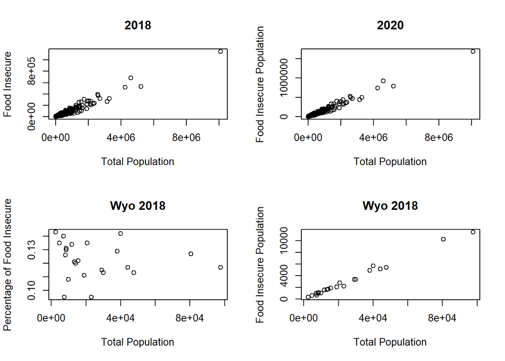

```r
##The Only thing you get out of these grapics is that no population means on food insecurity.
#par(mfrow = c(y,x)) produces a number of plots into a grid like fashion.
par(mfrow = c(2,2))
plot(corona$Total_Population, corona$X2018_Food_Insecurity_..1, xlab= "Total Population", ylab= "Food Insecure",main= "2018")
plot(corona$Total_Population, corona$X.C._2020_Food_Insecurity_..1, xlab="Total Population", ylab= "Food Insecure Population", main="2020")
#dev.off()

#par(mfrow = c(2,1))
#Basic Plots of Wyo Data
plot(covid_data_wy$Total_Population, covid_data_wy$X2018_Food_Insecurity_., xlab= "Total Population", ylab= "Percentage of Food Insecure",main= "Wyo 2018")
plot(covid_data_wy$Total_Population, covid_data_wy$X2018_Food_Insecurity_..1, xlab="Total Population", ylab= "Food Insecure Population", main="Wyo 2018")
```

```r
dev.off()
```

###The box plot is a good vissual to compare means and values. T-test is not the apropriate analysis as indicated by the ‘weird’ p values.

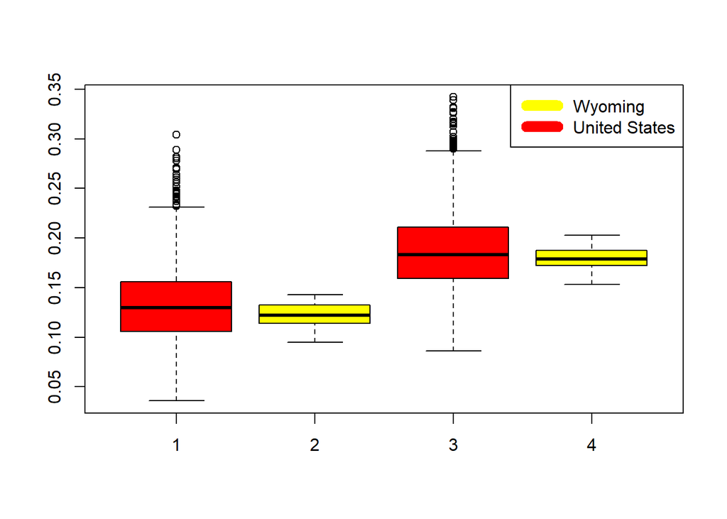

```r
boxplot(corona$X2018_Food_Insecurity_.,corona$X2018_Food_Insecurity_.[corona$State == "WY"], corona$X.C._2020_Food_Insecurity_.,corona$X.C._2020_Food_Insecurity_.[corona$State == "WY"], col = c("red", "yellow"))
legend("topright", c("Wyoming", "United States"), col=c("yellow", "red"), lwd=10)
```

```r
t.test(corona$X2018_Food_Insecurity_.,corona$X2018_Food_Insecurity_.[corona$State == "WY"])
```

```
##
##  Welch Two Sample t-test
##
## data:  corona$X2018_Food_Insecurity_. and corona$X2018_Food_Insecurity_.[corona$State == "WY"]
## t = 3.2801, df = 24.636, p-value = 0.003091
## alternative hypothesis: true difference in means is not equal to 0
## 95 percent confidence interval:
##  0.003488311 0.015284500
## sample estimates:
## mean of x mean of y
## 0.1319516 0.1225652
```

```r
#I do not understand why the p-Value <0.05

t.test(corona$X.C._2020_Food_Insecurity_.,corona$X.C._2020_Food_Insecurity_.[corona$State == "WY"])
```

```
##
##  Welch Two Sample t-test
##
## data:  corona$X.C._2020_Food_Insecurity_. and corona$X.C._2020_Food_Insecurity_.[corona$State == "WY"]
## t = 2.0341, df = 25.375, p-value = 0.05252
## alternative hypothesis: true difference in means is not equal to 0
## 95 percent confidence interval:
##  -6.272419e-05  1.075732e-02
## sample estimates:
## mean of x mean of y
## 0.1852603 0.1799130
```